# Introduction

I've always believed education to be the cornerstone of a functional society. The Programme for International Student Assessment (PISA) is a worldwide study by the Organisation for Economic Co-operation and Development in member and non-member nations intended to evaluate educational systems by measuring 15-year-old school pupils' scholastic performance on mathematics, science, and reading.

This project, part of my Udacity Nanodegree, is designed to showcase my ability to create visualisations using python. I have made use of the Matplotlib, Seaborn and Plotly libraries.

Subsequent slides will either show an insight to my thought process or a python coded graph accompanied with a short written analysis about the visualisation. For those who are interested, clicking on the graph will show the python code being used.

The PISA dataset has lots of information, from the amount of televisions a partiuclar student has at home to whether they actually enjoy doing mathematics tests.

The variable I plan on exploring is, the amount of parents at home, which is something I've always been curious about.

On the PISA homepage it's stated that the most useful columns for comparing the reading scores, mathematics scores and science scores are PV1MATH, PV1SCIE and PV1READ.

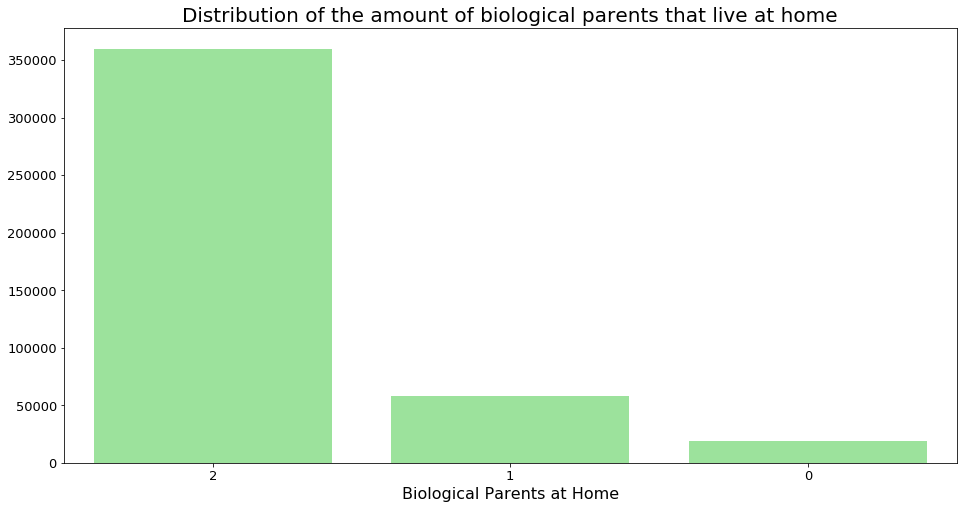

```python
# Plot bar chart showing the amount of parents at home each child has
plt.figure(figsize=(16,8))
sb.countplot(data = df_full_q2, x = 'parents_at_home', order = df_full_q2['parents_at_home'].value_counts().index, color = 'lightgreen')

plt.xlabel('Biological Parents at Home', fontsize = 16)
plt.ylabel('')
plt.title('Distribution of the amount of biological parents that live at home', fontsize = 20);
```

**Analysis:**

From the graph we can clearly see that the majority of students have both biological parents living at home. A much smaller amount of students have 1 biological parent living at home and having 0 biological parents at home is the least common.

```python
# Drop all non values in tardiness column in each dataset
bar0_subset = bar0_subset.dropna(subset=['ST08Q01'])
bar1_subset = bar1_subset.dropna(subset=['ST08Q01'])
bar2_subset = bar2_subset.dropna(subset=['ST08Q01'])
```

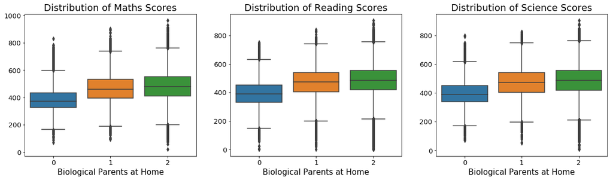

```python
# Create figure
plt.figure(figsize = [20, 5])
# Set color
base_color = sb.color_palette()[0];

# left plot: box plot of maths score
plt.subplot(1, 3, 1)
# Choose data
ax = sb.boxplot(x='parents_at_home', y='PV1MATH', data=df_full_q2)
# Set x label
plt.xlabel('Biological Parents at Home', fontsize=15)
# Remove y label
plt.ylabel('')
# Set title
plt.title('Distribution of Maths Scores', fontsize=18);

# middle plot: box plot of reading scores
plt.subplot(1, 3, 2)
ax = sb.boxplot(x='parents_at_home', y='PV1READ', data=df_full_q2)
plt.xlabel('Biological Parents at Home', fontsize=15)
plt.ylabel('')
plt.title('Distribution of Reading Scores', fontsize=18);

# right plot: box plot of science scores
plt.subplot(1, 3, 3)
ax = sb.boxplot(x='parents_at_home', y='PV1SCIE', data=df_full_q2)
plt.xlabel('Biological Parents at Home', fontsize=15)
plt.ylabel('')
plt.title('Distribution of Science Scores', fontsize=18);
```

**Analysis:**

From the three box plots we can see that having 2 biological parents at home has a positive affect on the average scores for mathematics (PV1MATH), science (PV1SCIE) and reading (PV1READ). Children not having any biological parents had the lowest mean scores for all subjects but also these children, with no biological parents at home, had the smallest range of values. On the contrary, parents with both biological parents at home had the largest range of values.

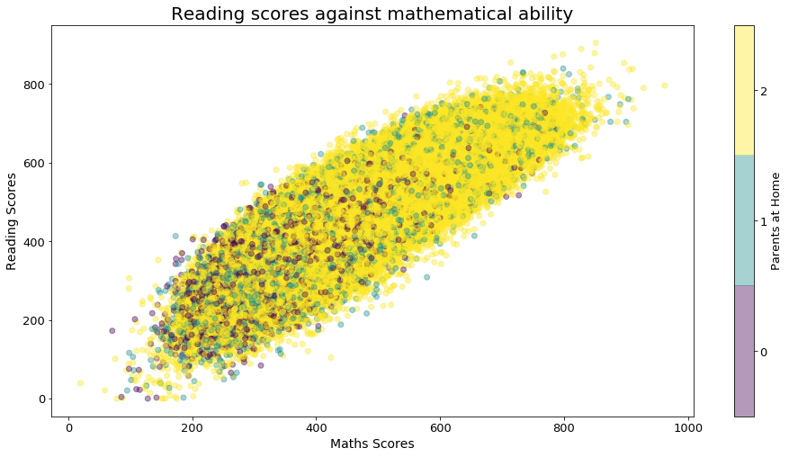

```python
# Create figure
plt.figure(figsize = [16, 8])
# Plot scatter using data
plt.scatter(data = df_full_q2, x = 'PV1MATH', y = 'PV1READ', c = 'parents_at_home', cmap=plt.cm.get_cmap('viridis', 3), alpha = 0.4)
# Plot the title
plt.title('Reading scores against mathematical ability', fontsize=20)
# Plot y label
plt.ylabel('Reading Scores', fontsize=14)
# Plot x label
plt.xlabel('Maths Scores', fontsize=14)
# Create colour legend
plt.colorbar(ticks=range(3), label='Parents at Home')
# Set limits of ticks on colour bar
plt.clim(-0.5, 2.5);
```

**Analysis:**

Our bivariate analysis showed us that there is a strong positive correlation between reading scores and mathematical ability. Adding in the amount of parents at home as a colour dependent variable shows that the children with no biological parents at home, represented by the darker circles, appear to clump in the bottom left portion of the distribution which corresponds to lower readings and mathematics scores. The top end of the spectrum is made up mainly children with two parents.

### Conclusion

What we've learned during this project, is that having both biological parents at home makes a substantial positive difference to the maths, science and reading scores.